# UCSF Stages Data - Prelim Analysis

Steph Reynolds (Stephanie.Reynolds@ucsf.edu)

Dec 29, 2021 10:34 AM

# Background

## Project

MINDSCAPE: Modeling of infectious network dynamics for surveillance, control and prevention enhancement

## Description

This file summarizes the data, creates descriptive tables for the continuous and categorical variables, and generates plots to show the distrbution of length of stay (LOS) by admission stage.

## Source Data

- Demographics and Daily Covid Stage Data (`dm_stg_unique_pt_11.08.2021.csv`)
  - This file contains data on patient demographics and COVID stage (based on WHO Clinical Progression Scale, which aims to capture patient clinical trajectory and resource usage over the course of the clinical illness – in this case, COVID-19).
  - Each row contains a different patient as shown by their unique encounter ID.

# Load required packages

# Import and preview data

| ID | age | sex | zip | race | ethnicity | smoking | BMI | LOS | stage | max_stage | date_adm | date_disc | stage_adm | stage_disc | DOD | death |
| --- | --- | --- | --- | --- | --- | --- | --- | --- | --- | --- | --- | --- | --- | --- | --- | --- |
| 0055f0c4-990c-44ce-911e-4b1784666eeb | 53 | Male | 95382 | Other | Hispanic or Latino | Not Current Smoker | 31.58 | 9 | 5 | 6 | 2020-10-19 | 2020-10-28 | 5 | 5 | NA | No |
| 00a80297-7016-4b06-8dfc-21a1490baafa | 57 | Male | 94939 | White or Caucasian | Not Hispanic or Latino | Current Smoker | 42.03 | 8 | 5 | 6 | 2021-01-04 | 2021-01-12 | 5 | 5 | NA | No |
| 01abe61d-6df2-4f18-9a85-8b8d12f94f08 | 51 | Male | 93722 | White or Caucasian | Hispanic or Latino | Not Current Smoker | 28.59 | 9 | 4 | 5 | 2020-12-04 | 2020-12-13 | 4 | 4 | NA | No |
| 01b4c414-b32c-46dc-8c2a-29f399147f70 | 67 | Male | 94901 | White or Caucasian | Hispanic or Latino | Not Current Smoker | 27.21 | 8 | 4 | 4 | 2020-08-10 | 2020-08-18 | 4 | 4 | NA | No |
| 01ef2f14-8a20-4d6f-9942-12fa0a4b6f2d | 66 | Female | 94553-5927 | White or Caucasian | Not Hispanic or Latino | Not Current Smoker | 28.22 | 2 | 5 | 5 | 2020-12-07 | 2020-12-09 | 5 | 5 | NA | No |
| 020b86bb-0f9e-4335-a430-7f879ca15f89 | 83 | Female | 94110 | Other | Hispanic or Latino | Not Current Smoker | 22.37 | 12 | 4 | 4 | 2021-01-29 | 2021-02-11 | 4 | 4 | NA | No |

|  | vars | n | mean | sd | median | trimmed | mad | min | max | range | skew | kurtosis | se | Q0.25 | Q0.75 |
| --- | --- | --- | --- | --- | --- | --- | --- | --- | --- | --- | --- | --- | --- | --- | --- |
| ID* | 1 | 1117 | 559.000000 | 322.5944306 | 559.000 | 559.000000 | 413.645400 | 1.00 | 1117.0 | 1116.00 | 0.0000000 | -1.2032234 | 9.6522882 | 280.0000 | 838.0000 |
| age | 2 | 1117 | 58.633841 | 19.6280202 | 60.000 | 58.691620 | 22.239000 | 18.00 | 104.0 | 86.00 | -0.0638805 | -0.7475971 | 0.5872864 | 44.0000 | 72.0000 |
| sex* | 3 | 1117 | 1.515667 | 0.4999783 | 2.000 | 1.519553 | 0.000000 | 1.00 | 2.0 | 1.00 | -0.0626145 | -1.9978656 | 0.0149598 | 1.0000 | 2.0000 |
| zip* | 4 | 1117 | 252.002686 | 145.9655499 | 232.000 | 246.674860 | 170.499000 | 1.00 | 542.0 | 541.00 | 0.2865177 | -1.0240640 | 4.3674082 | 134.0000 | 369.0000 |
| race* | 5 | 1117 | 3.928380 | 1.9050655 | 4.000 | 4.034637 | 2.965200 | 1.00 | 6.0 | 5.00 | -0.3637659 | -1.2949108 | 0.0570011 | 2.0000 | 6.0000 |
| ethnicity* | 6 | 1117 | 1.708147 | 0.5122652 | 2.000 | 1.725140 | 0.000000 | 1.00 | 3.0 | 2.00 | -0.2785078 | -0.6415936 | 0.0153274 | 1.0000 | 2.0000 |
| smoking* | 7 | 1117 | 2.028648 | 0.3630359 | 2.000 | 2.000000 | 0.000000 | 1.00 | 3.0 | 2.00 | 0.3617360 | 4.4764448 | 0.0108623 | 2.0000 | 2.0000 |
| BMI | 8 | 1076 | 28.459117 | 7.8566768 | 27.195 | 27.692842 | 6.827373 | 11.55 | 79.2 | 67.65 | 1.4364896 | 4.1675891 | 0.2395150 | 23.0425 | 32.2975 |
| LOS | 9 | 1117 | 12.967771 | 18.3847480 | 7.000 | 9.131844 | 5.930400 | 1.00 | 231.0 | 230.00 | 4.6257148 | 32.0941170 | 0.5500866 | 4.0000 | 14.0000 |
| stage | 10 | 1117 | 4.987466 | 1.3710474 | 5.000 | 4.665922 | 1.482600 | 4.00 | 9.0 | 5.00 | 1.7753551 | 2.3722953 | 0.0410229 | 4.0000 | 5.0000 |
| max_stage | 11 | 1117 | 5.897046 | 1.9595278 | 5.000 | 5.642458 | 1.482600 | 4.00 | 10.0 | 6.00 | 1.0127709 | -0.4377047 | 0.0586307 | 5.0000 | 7.0000 |
| date_adm | 12 | 1117 | NaN | NA | NA | NaN | NA | Inf | -Inf | -Inf | NA | NA | NA | NA | NA |
| date_disc | 13 | 1117 | NaN | NA | NA | NaN | NA | Inf | -Inf | -Inf | NA | NA | NA | NA | NA |
| stage_adm | 14 | 1117 | 4.987466 | 1.3710474 | 5.000 | 4.665922 | 1.482600 | 4.00 | 9.0 | 5.00 | 1.7753551 | 2.3722953 | 0.0410229 | 4.0000 | 5.0000 |
| stage_disc | 15 | 1117 | 4.850492 | 1.6880436 | 4.000 | 4.366480 | 0.000000 | 4.00 | 10.0 | 6.00 | 2.3925973 | 4.4757112 | 0.0505076 | 4.0000 | 5.0000 |
| DOD | 16 | 94 | NaN | NA | NA | NaN | NA | Inf | -Inf | -Inf | NA | NA | NA | NA | NA |
| death* | 17 | 1117 | 1.084154 | 0.2777430 | 1.000 | 1.000000 | 0.000000 | 1.00 | 2.0 | 1.00 | 2.9917858 | 6.9570132 | 0.0083103 | 1.0000 | 1.0000 |

# Create table one for categorical and continuous variables

|  | Overall |
| --- | --- |
| n | 1117 |
| sex = Male (%) | 576 (51.6) |
| race (%) |  |
| Asian | 221 (19.8) |
| Black or African American | 110 ( 9.8) |
| Native Hawaiian or Other Pacific Islander | 18 ( 1.6) |
| Other | 341 (30.5) |
| Unknown | 33 ( 3.0) |
| White or Caucasian | 394 (35.3) |
| ethnicity (%) |  |
| Hispanic or Latino | 357 (32.0) |
| Not Hispanic or Latino | 729 (65.3) |
| Unknown | 31 ( 2.8) |
| smoking (%) |  |
| Current Smoker | 58 ( 5.2) |
| Not Current Smoker | 969 (86.8) |
| Smoking Status Unknown | 90 ( 8.1) |
| death = Yes (%) | 94 ( 8.4) |

|  | Overall |
| --- | --- |
| n | 1117 |
| age (mean (SD)) | 58.63 (19.63) |
| BMI (mean (SD)) | 28.46 (7.86) |
| LOS (mean (SD)) | 12.97 (18.38) |

# Stage transition matrices

|  | 4 | 5 | 6 | 7 | 8 | 9 | p | test |
| --- | --- | --- | --- | --- | --- | --- | --- | --- |
| n | 517 | 397 | 79 | 11 | 50 | 63 |  |  |
| stage_disc (%) |  |  |  |  |  |  | <0.001 |  |
| 4 | 435 (84.1) | 200 (50.4) | 29 (36.7) | 4 (36.4) | 20 (40.0) | 17 (27.0) |  |  |
| 5 | 55 (10.6) | 162 (40.8) | 32 (40.5) | 0 ( 0.0) | 14 (28.0) | 19 (30.2) |  |  |
| 6 | 3 ( 0.6) | 5 ( 1.3) | 2 ( 2.5) | 0 ( 0.0) | 0 ( 0.0) | 1 ( 1.6) |  |  |
| 7 | 3 ( 0.6) | 1 ( 0.3) | 2 ( 2.5) | 6 (54.5) | 5 (10.0) | 3 ( 4.8) |  |  |
| 8 | 0 ( 0.0) | 0 ( 0.0) | 0 ( 0.0) | 1 ( 9.1) | 1 ( 2.0) | 1 ( 1.6) |  |  |
| 9 | 0 ( 0.0) | 0 ( 0.0) | 1 ( 1.3) | 0 ( 0.0) | 0 ( 0.0) | 1 ( 1.6) |  |  |
| 10 | 21 ( 4.1) | 29 ( 7.3) | 13 (16.5) | 0 ( 0.0) | 10 (20.0) | 21 (33.3) |  |  |

|  | 4 | 5 | 6 | 7 | 8 | 9 | p | test |
| --- | --- | --- | --- | --- | --- | --- | --- | --- |
| n | 517 | 397 | 79 | 11 | 50 | 63 |  |  |
| max_stage (%) |  |  |  |  |  |  | <0.001 |  |
| 4 | 251 (48.5) | 0 ( 0.0) | 0 ( 0.0) | 0 ( 0.0) | 0 ( 0.0) | 0 ( 0.0) |  |  |
| 5 | 203 (39.3) | 273 (68.8) | 0 ( 0.0) | 0 ( 0.0) | 0 ( 0.0) | 0 ( 0.0) |  |  |
| 6 | 10 ( 1.9) | 55 (13.9) | 42 (53.2) | 0 ( 0.0) | 0 ( 0.0) | 0 ( 0.0) |  |  |
| 7 | 1 ( 0.2) | 1 ( 0.3) | 0 ( 0.0) | 4 (36.4) | 0 ( 0.0) | 0 ( 0.0) |  |  |
| 8 | 16 ( 3.1) | 18 ( 4.5) | 5 ( 6.3) | 4 (36.4) | 25 (50.0) | 0 ( 0.0) |  |  |
| 9 | 15 ( 2.9) | 21 ( 5.3) | 19 (24.1) | 3 (27.3) | 15 (30.0) | 42 (66.7) |  |  |
| 10 | 21 ( 4.1) | 29 ( 7.3) | 13 (16.5) | 0 ( 0.0) | 10 (20.0) | 21 (33.3) |  |  |

# Create histogram of LOS

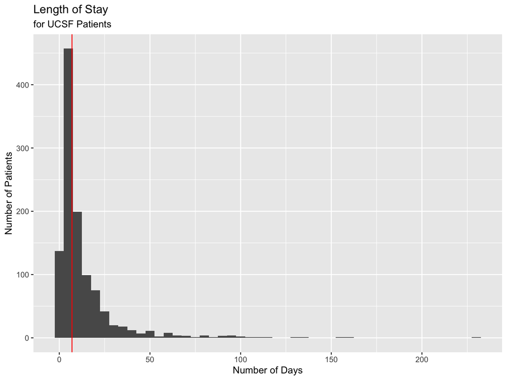

# Create barplot showing distribution of max stages

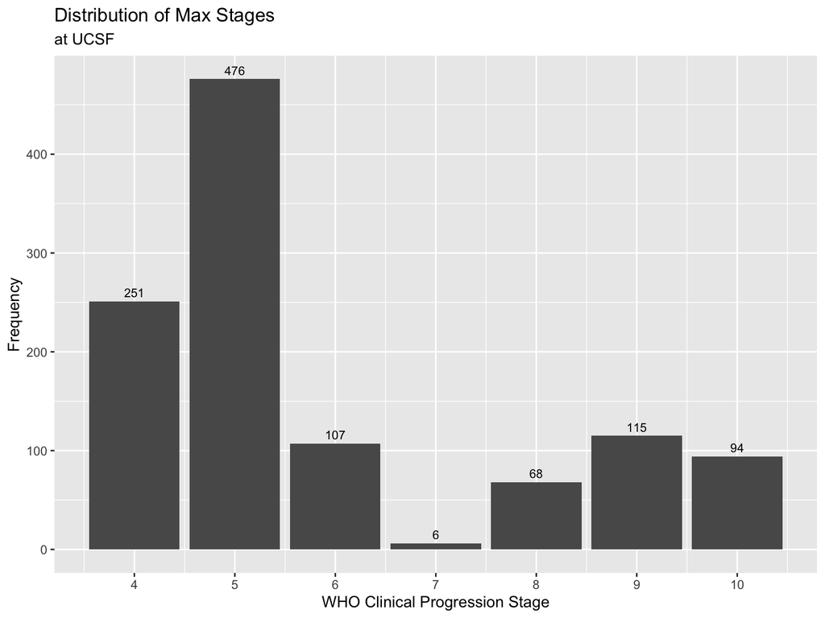

# Run correlation stats

```
##
##  Pearson's product-moment correlation
##
## data:  df$max_stage and df$LOS
## t = 18.781, df = 1115, p-value < 2.2e-16
## alternative hypothesis: true correlation is not equal to 0
## 95 percent confidence interval:
##  0.4443494 0.5335412
## sample estimates:
##       cor
## 0.4902276
```

```
##
##  Pearson's product-moment correlation
##
## data:  df$max_stage and df$stage_disc
## t = 33.663, df = 1115, p-value < 2.2e-16
## alternative hypothesis: true correlation is not equal to 0
## 95 percent confidence interval:
##  0.6796087 0.7378902
## sample estimates:
##       cor
## 0.7099629
```

```
##
##  Pearson's product-moment correlation
##
## data:  df$max_stage and df$stage_adm
## t = 28.528, df = 1115, p-value < 2.2e-16
## alternative hypothesis: true correlation is not equal to 0
## 95 percent confidence interval:
##  0.6143151 0.6822269
## sample estimates:
##       cor
## 0.6495647
```

# Create proportional stacked bar chart to show proportion of max_stage within stage_adm

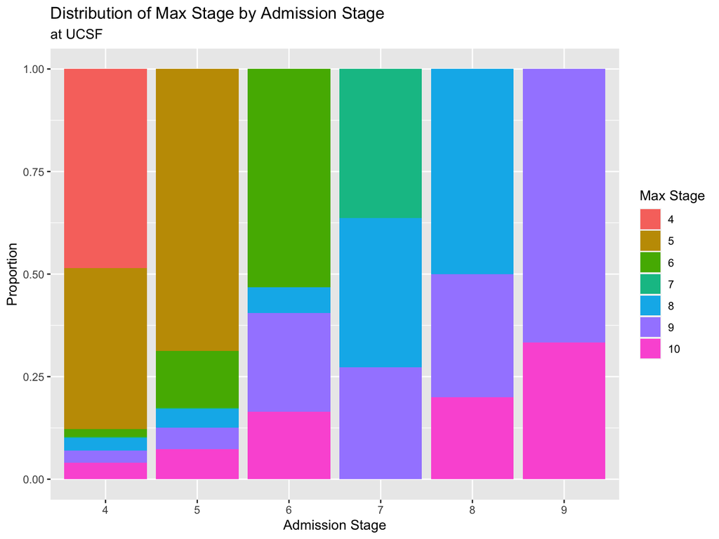

# Create boxplot of LOS grouped by admission stage

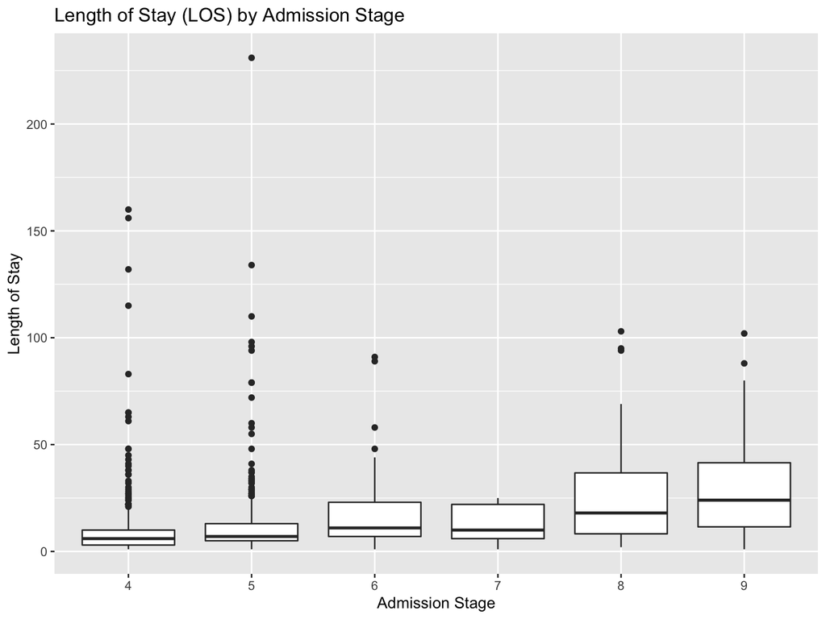

# Transform admission stage, discharge stage, and max stage to stage categories where 4-5 = moderate, 6-9 = severe, and 10 = dead

```
## [1] "Moderate" "Severe"   "Dead"
```

```
## [1] "Moderate" "Severe"   "Dead"
```

```
## [1] "Moderate" "Severe"   "Dead"
```

# Re-run the proportional stacked bar chart and boxplot from above using stage categories (moderate, severe, dead)

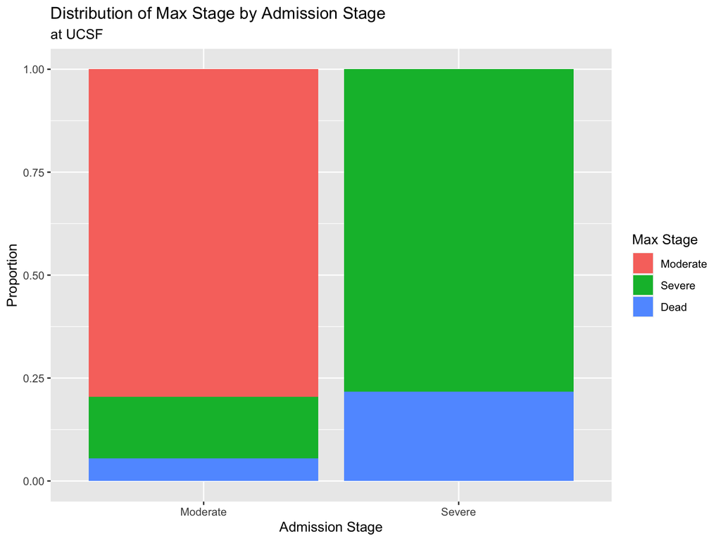

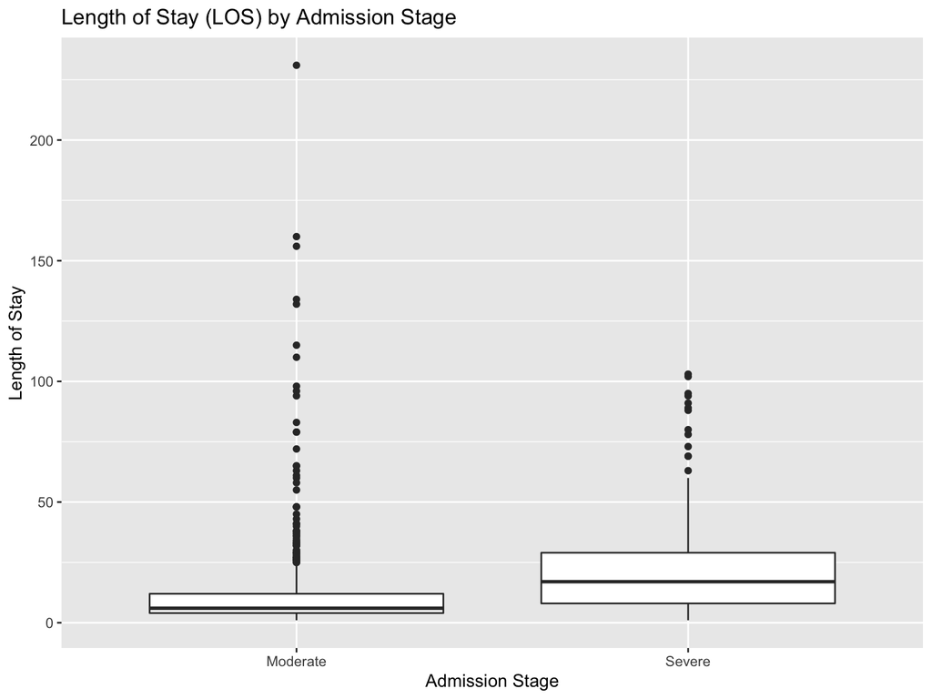